# Supervised Learning

Oriol Tauleria

13 February 2022

# Detección de ataques con aprendizaje supervisado

El siguiente ejercicio consiste en crear un modelo entrenado capaz de detectar ataques a partir de logs de un firewall. Para este propósito, se realizará una prueba de concepto con una pequeña muestra de logs previamente etiquetados como tráfico normal o ataque.

## Data sets

Se proporcionan los siguentes archivos:

- features.csv
- events.csv

### Events analysis

Para estudiar los eventos es importante tener claro el significado de cada una de los campos de los mismos:

```
##    No.             Name      Type
## 1    1            srcip   nominal
## 2    2            sport   integer
## 3    3            dstip   nominal
## 4    4           dsport   integer
## 5    5            proto   nominal
## 6    6            state   nominal
## 7    7              dur     Float
## 8    8           sbytes   Integer
## 9    9           dbytes   Integer
## 10  10             sttl   Integer
## 11  11             dttl   Integer
## 12  12            sloss   Integer
## 13  13            dloss   Integer
## 14  14          service   nominal
```

[output cut: 85 more lines]

Con esta información en mente, podemos hacer un análisis superficial y empezar a trabajar en la limpieza de los datos (de la que hablaremos mas adelante).

Por otro lado, al hacer una exploración visual, no detectamos muchos campos con muchos errores (NAN, NULLS, etc.) por lo tanto no realizaremos una limpieza exhaustiva. Es importante tener en cuenta que es probable que estos datos hayan sido preprocesados debido a la calidad de los mismos.

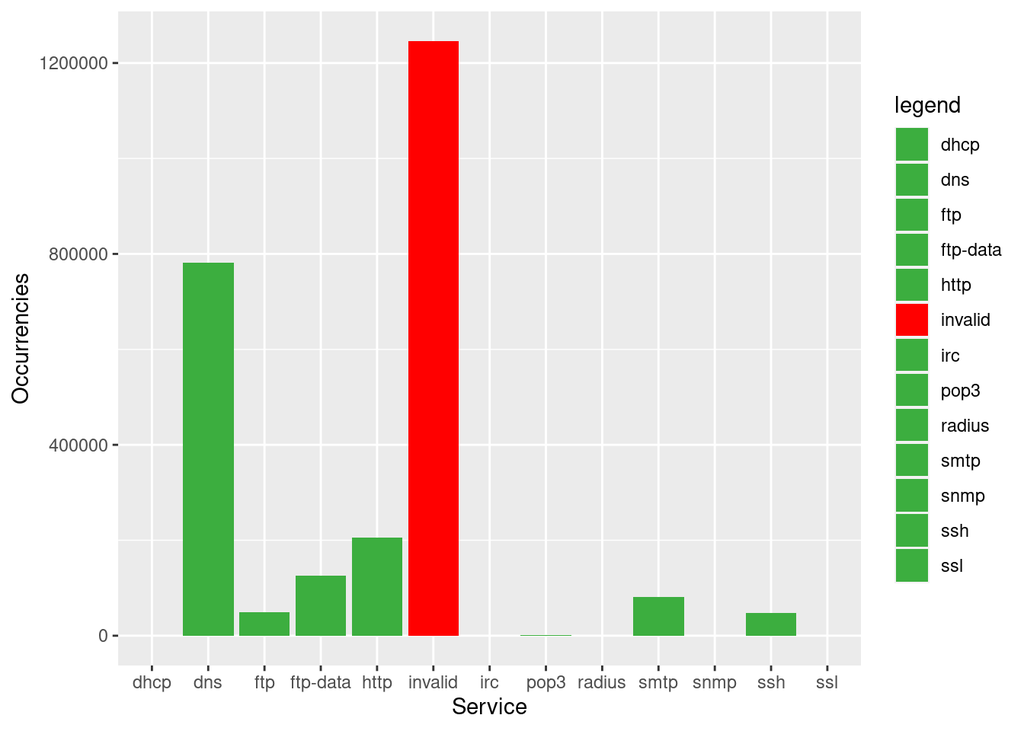

Por otro lado, la diferencia, normal, cuando estamos trabajando con eventos de distintos protocolos. Debido a las significativas diferencias entre los distintos protocolos, seria interesante estudiarlos por separado si quisieramos tener insights con mucho mas detalle. Se hace este apunte para remarcar que las informaciones pueden diferir mucho entre unos y otros. Especialmente entre el grupo TCP y UDP y los demás, De todas formas, asumiendo que un 98% del tráfico es TCP+UDP, trabajaremos con todo el dataset.

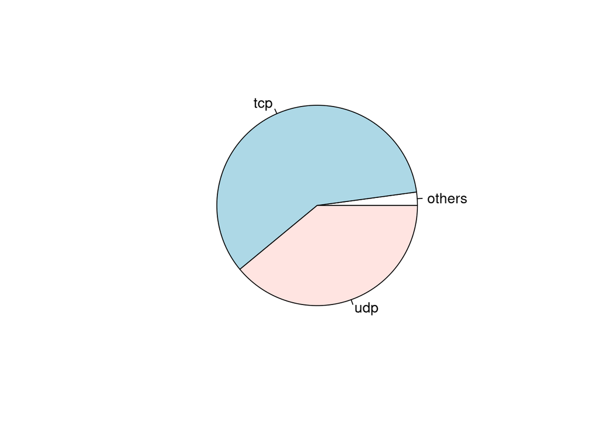

### Datos “a no tener en cuenta”

Hay algunos datos, que por su naturaleza, es recomendable quitar del análisis del modelo para evitar falsos positivos, vamos a verlos.

#### srcip

Este campo, que indica la IP origen del ataque, es un campo que no nos ayuda a predecir a futuro, pero si nos puede ensuciar, fácilmente, el pasado. Este campo sería muy útil para hacer un análisis forense de un ataque, pero muy poco útil para predecir futuros ataques.

#### dstip

Este campo, que indica la IP a las que se le han realizado los ataques (nuestras IPs), tampoco nos ayuda a predecir a futuro, en todo caso, podríamos analizar qué IPs reciben mas intentos de ataque, pero no es el objetivo de este modelo.

### Datos significativamente importantes

Al lanzar algunas simulaciones, recibimos información sobre qué correlaciones son mas altas, (mas adelante entraremos mas al detalle, pero es importante plantear algunas preguntas en este punto.)

#### ctstatettl

Este campo, (ct state ttl), tal y como nos indica la tabla de referencia, es un valor calculado. Por lo tanto podría ser suceptible de estar calculado a posteriori añadiendo información de la que no se dispone al instante. Los campos calculados pueden añadir una probabilidad de error mas alta, que un campo que es una pura observación.

Para decidir si es un dato imprescindible o no, será interesante trabajar tanto “con” como “sin” este dato.

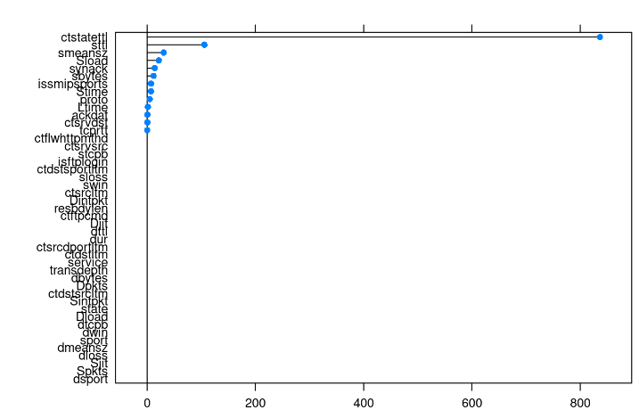

ctstatettl accuracy

### Data enrichment

Al realizar los distintos entrenados del modelo hemos detectado un éxito alto, por lo que no ha sido necesario añadir datos de otras fuentes. Sin embargo hay algunos datos externos con los que seria interesante trabajar para sacar conclusiones que puedan ayudar incluso mas al análisis. Por ejemplo determinar si geográficamente hay alguna relación entre las IPs orígenes que nos estan realizando los ataques, o si hay relación en cuanto al propietario.

## Feature engineering

Al realizar distintos entrenamientos del modelo detectamos algunos campos que nos “engañan” y otros que por si solos ya nos ofrecen soluciones con una alta precisión. Para incorporar este conocimiento se han realizado approaches distintos al seleccionar que datos se trabajan en el entrenamiento. Empezando por un approach genérico de eliminar datos que inducian a errores significativos (como el ya mencionado attackcat) o que limitan el uso del modelo para futuros usos (como srcip, dstip). Una vez realizada esta “limpieza” se ha procedido a una aproximación mucho mas específica con los datos que mejores resultados han reportado en distintos entrenamientos (ctstatettl, smeansz, sbytes, ackdat…).

```
##
##   ATTACK   NORMAL
## 0.126487 0.873513
```

## Build model

### Create train and test data sets

### Train model

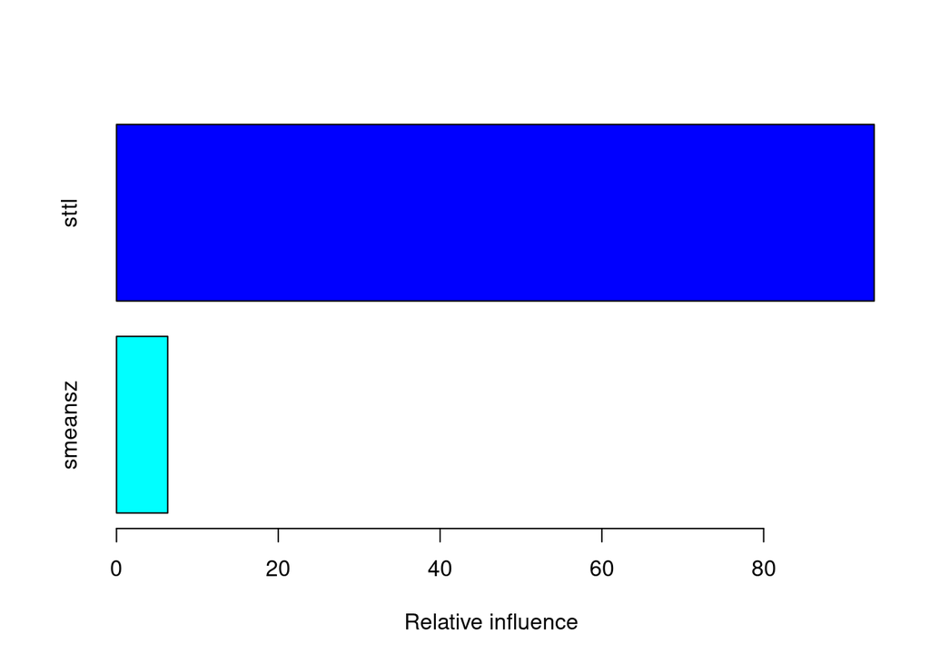

```
##             var   rel.inf
## sttl       sttl 93.667712
## smeansz smeansz  6.332288
```

### Test model

```
## [1] NORMAL NORMAL NORMAL NORMAL NORMAL ATTACK
## Levels: ATTACK NORMAL
```

## Evaluate model

```
##  Accuracy     Kappa
## 0.9893073 0.9527324
```

```r
# probabilites
predictions <- predict(object=objModel, testDF[,predictorsNames], type='prob')
auc <- roc(ifelse(testDF[,outcomeName]=="ATTACK",1,0), predictions[[2]])
print(auc$auc)
```

```
## Area under the curve: 0.999
```

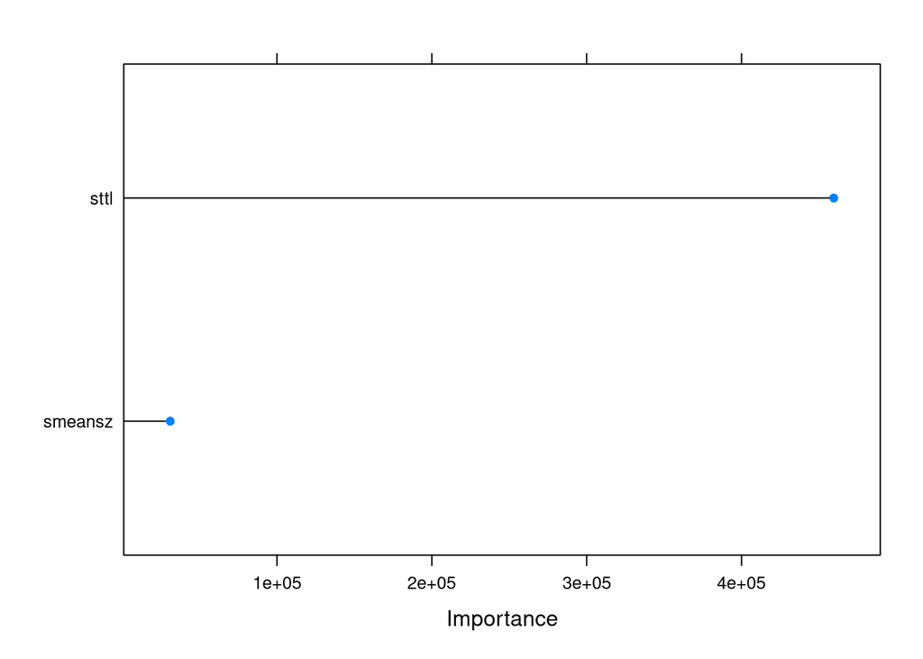

```r
plot(varImp(objModel,scale=F))
```

## Conclusion

Podemos concluir que el dataset nos permite hacer predicciones muy precisas, con ciertamente pocos datos. El campo “ctstatettl” nos da una precisión altísima, pero por desconocimiento del cálculo (y de la fiabilidad del mismo) para generar este dato, se ha optado por utilizar otros 2 campos que tambien otorgan una fiabilidad muy alta. (“sttl” y “smeansz”). Con esto concluimos que sabiendo la media del tamaño de paquetes enviados y el tiempo de vida de las conexiones “orígen - destino” podemos identificar con una alta precisión si se trata de un ataque o no.

Como hemos comentado en puntos anteriores, seria interesante hacer enrichment de los datos, para poder detectar incluso con mas celeridad cualquier ataque (orígenes geográficos, o de propiedad) por ejemplo.

También recomendariamos hacer enrichment con qué destinos son los que reciben mas ataques (identificando OSs, versiones de framework o de servicios expuestos, etc.). Con esta información no es descabellado pensar que se podrían determinar qué assets serán atacados en un futuro con mas probabilidad, pudiendo proteger estos elementos de forma mas intensa, o incluyendo honey pots; es decir, utilizando utilizando herramientas de Defensa Activa, tal y como recomienda el framework SHIELD de MITRE.